# Лабораторная работа №3

Дискреционное разграничение прав в Linux.

Устинова В. В.

Российский университет дружбы народов, Москва, Россия

13 марта 2026

# Информация

## Докладчик

- Устинова Виктория Вадимовна
- студент НПИбд-01-24
- Российский университет дружбы народов

## Цель работы

Получение практических навыков работы в консоли с атрибутами файлов для групп пользователей

## Выполнение лабораторной работы

В установленной операционной системе создайте учётную запись пользователя guest2, задайте пароль для пользователя guest2

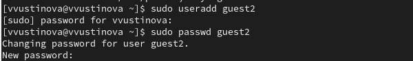

создаем нового пользователя и задаем ему пароль

## Работа с двумя пользователями

Добавьте пользователя guest2 в группу guest:

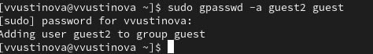

вводим новую команду

## Работа с двумя пользователями

Осуществите вход в систему от двух пользователей на двух разных консолях: guest на первой консоли и guest2 на второй консоли

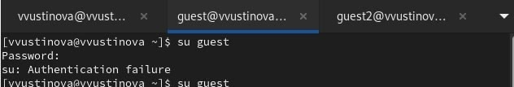

Входим в пользователей

## Работа с двумя пользователями

Осуществите вход в систему от двух пользователей на двух разных консолях: guest на первой консоли и guest2 на второй консоли

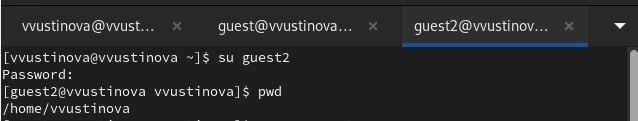

Входим в пользователей и смотрим директорию

## Работа с двумя пользователями

Определите командами groups guest и groups guest2, в какие группы входят пользователи guest и guest2. Сравните вывод команды groups с выводом команд id -Gn и id -G.

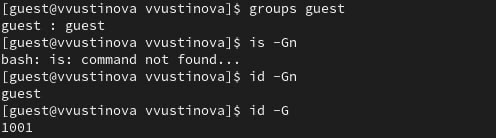

Группа guest

## Работа с двумя пользователями

Определите командами groups guest и groups guest2, в какие группы входят пользователи guest и guest2. Сравните вывод команды groups с выводом команд id -Gn и id -G.

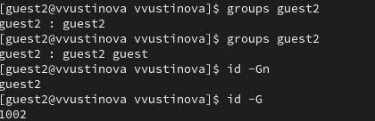

Группы guest and guesr2

## Работа с двумя пользователями

Сравните полученную информацию с содержимым файла /etc/group, от имени пользователя guest измените права директории /home/guest, разрешив все действия для пользователей группы:

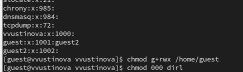

Одинаковый вывод

## Работа с двумя пользователями

От имени пользователя guest снимите с директории /home/guest/dir1, и проверьте правильность снятия атрибутов

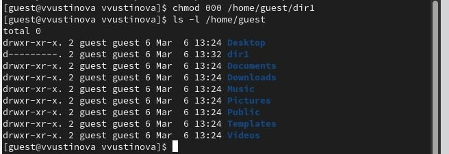

Сняты верно

## Выводы

Мы успешно получили практические навыки работы в консоли с атрибутами файлов для групп пользователей